# Machine learning

Week 9: uncertainty and interpretation

What is the best prediction of an outcome if the loss is squared error? If it is absolute error? If a miss costs ten times a false alarm?

## Where we left off

| Loss | Best prediction at $x$ |  |
| --- | --- | --- |
| Squared error, $(y - \hat y)^2$ | the conditional mean, $\mathbb E[Y \mid X = x]$ | optimal model theorem |
| Absolute error, $\lvert y - \hat y \rvert$ | the conditional median | stated |
| A miss costs $c_{FN}$, a false alarm $c_{FP}$ | predict $1$ when $p(x) > c^\star = \frac{c_{FP}}{c_{FP} + c_{FN}}$ | optimal threshold theorem |

**Decision principle**: choose the prediction $\hat y$ that minimizes the expected loss given the inputs, $\mathbb E[\ell(Y, \hat y) \mid X = x]$

### Week 9: uncertainty and interpretation

Part 1: regression uncertainty and intervals

Part 2: classification uncertainty and calibration

Part 3: interpreting the model

Part 4: the model and the world

### Part 1: regression uncertainty and intervals

## A prediction for one person

So far, competitors submit models that predict, and the winning model is chosen by best score on the evaluation dataset: an average over many people

Now the winning model is deployed. A new person arrives with inputs $x_0$ and is told $\hat f(x_0)$. How far off might that be?

You are that person. What should a “90% interval” for your outcome promise you?

That the interval, call it $\hat C(x_0)$, covers outcomes of people with your inputs 90% of the time: $P\big(Y \in \hat C(X) \mid X = x_0\big) \ge 0.9$, **conditional coverage**

## Two kinds of interval

At a new $x_0$, $Y_0 = f^\star(x_0) + \varepsilon_0$

- **Confidence interval** for $f^\star(x_0)$ (dark): uncertainty about the fit; it narrows as $n$ grows
- **Prediction interval** for $Y_0$ (light): must also cover $\varepsilon_0$; it does not narrow below the noise

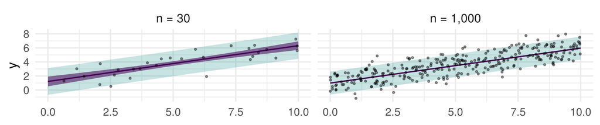

Bias–variance at $x_0$: $\sigma^2 + \text{bias}^2 + \text{variance}$; no amount of data shrinks $\sigma^2$

## An interval $\hat f(x_0) \pm C$

The simplest interval: $\hat C(x_0) = \big[\hat f(x_0) - C,\ \hat f(x_0) + C\big]$, for a number $C$

How could we compute $C$ for each kind of interval, for $f^\star(x_0)$ and for $Y_0$?

- $f^\star(x_0)$: how much $\hat f(x_0)$ varies between samples (a standard error, the bootstrap)
- $Y_0$: how far outcomes fall from predictions, a **quantile** of the absolute residuals $|y_i - \hat f(x_i)|$

Squared loss: the mean. Absolute loss: the median. Which loss: the 90th percentile?

## Finding the quantile

Charge $\tau$ for each unit of underprediction ($y > \hat y$) and $1 - \tau$ for each unit of overprediction ($y < \hat y$). Move the prediction up from $\hat y$ to $\hat y + \delta$:

- an outcome above $\hat y$: its loss falls by $\tau\delta$
- an outcome below $\hat y$: its loss rises by $(1 - \tau)\delta$

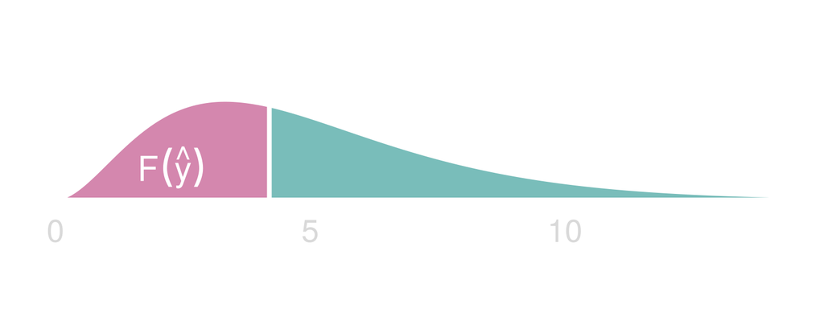

With $F$ the distribution function of $Y$ given $X = x$, the expected change is about
$$\delta\,\big[(1 - \tau)F(\hat y) - \tau\,(1 - F(\hat y))\big] = \delta\,\big[F(\hat y) - \tau\big]$$

Keep moving up while $F(\hat y) < \tau$; stop where $F(\hat y) = \tau$: the **$\tau$-quantile**. For the 90th percentile, $\tau = 0.9$

## Quantile optimality

**Pinball loss**:
$$\rho_\tau(y - \hat y) = (y - \hat y)\,\big(\tau - \mathbf 1\{y < \hat y\}\big)$$
$\tau\,(y - \hat y)$ for an underprediction, $(1 - \tau)(\hat y - y)$ for an overprediction. With $\tau = \frac12$, half the absolute error

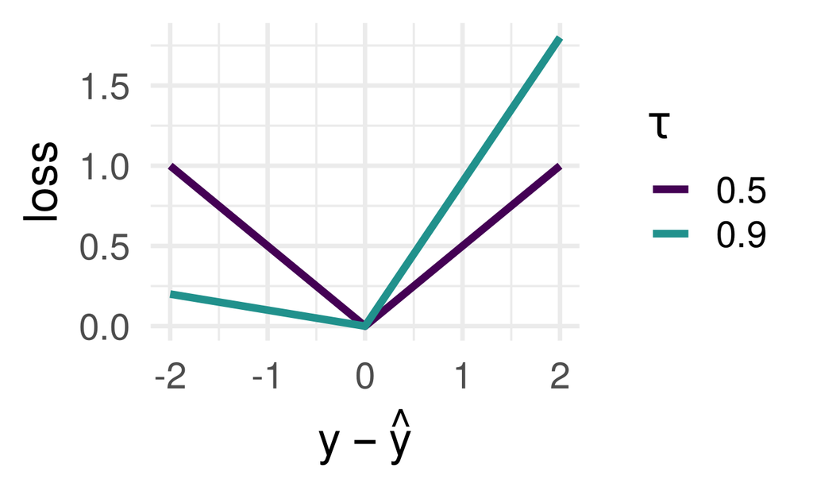

**Quantile optimality theorem.** If $Y \mid X = x$ has a continuous distribution with a finite mean and $0 < \tau < 1$, then the conditional $\tau$-quantile $q_\tau(x)$ minimizes $\mathbb E[\rho_\tau(Y - \hat y) \mid X = x]$ over $\hat y$ (uniquely, unless the distribution function is flat at $\tau$)

Squared loss gave the mean; half the absolute error, $\tau = \frac12$, gives the median

## Quantile regression

Minimize the average pinball loss over a class: $\hat q_\tau = \arg\min_{f \in \mathcal F} \frac1n \sum_i \rho_\tau\big(y_i - f(x_i)\big)$. Here $\mathcal F$ is linear; 1,000 simulated points: noise that grows with $x$, a bump at 3, few points with $x$ between 4 and 6

```r
fit_qr <- rq(y ~ x, tau = c(0.05, 0.5, 0.95), data = het_train)
```

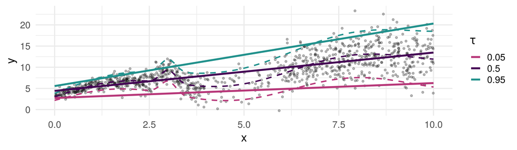

## The same loss, a flexible model

Boosted trees with the pinball loss: each tree is built from the negative gradient $\tau - \mathbf 1\{y_i < \hat f(x_i)\}$, which pushes the fit up where points lie above it

```r
xgboost(x, y, objective = "reg:quantileerror", quantile_alpha = 0.95, max_depth = 2)
```

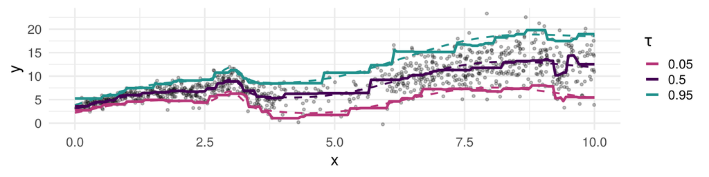

Boosting: each small tree approximates the negative gradient of the training loss

## Challenges with local intervals

A **local** interval’s edges change with $x$: $\hat C(x) = [\hat q_{0.05}(x), \hat q_{0.95}(x)]$, two quantile fits

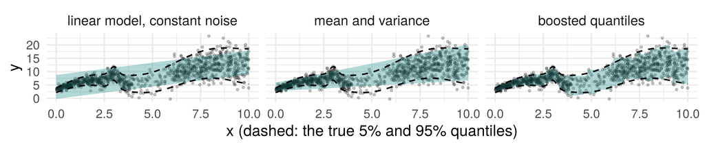

- Edges near $x$ come from rows near $x$: few in 4 to 6; at 3 the quantiles change fast
- Extreme quantiles are harder to learn than the mean: 1 row in 20 lies beyond each edge
- Rigid models (left, middle) use every row at every $x$: stable, wrong where they misfit

## Checking an interval

We claim 90 percent intervals. With fresh data in hand, how do you check the claim, and what could the check miss?

## Checking an interval on fresh data

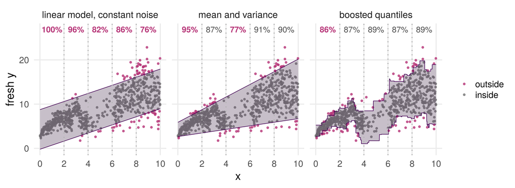

Top: coverage in each range of $x$, pink if more than 3 points from 90%. Overall: 89%, 90%, 87%. Widening never lowers coverage: check width too

## Bias, variance and intervals

$\hat f(x) \pm C$, with $C$ the 90th percentile of the absolute residuals on the **training** rows

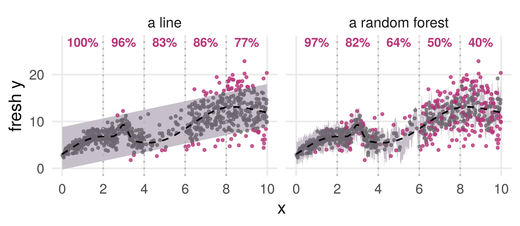

- **Bias**: the line misses the bends
- **Variance**: the forest follows the noise in its own rows; residuals there are too small
- **One $C$** for every $x$, though the noise grows

How could we choose $C$ so that the forest’s interval covers 90% of new outcomes?

## Residuals from held-out rows

The forest again, its node size now tuned on 1,000 **tuning** rows

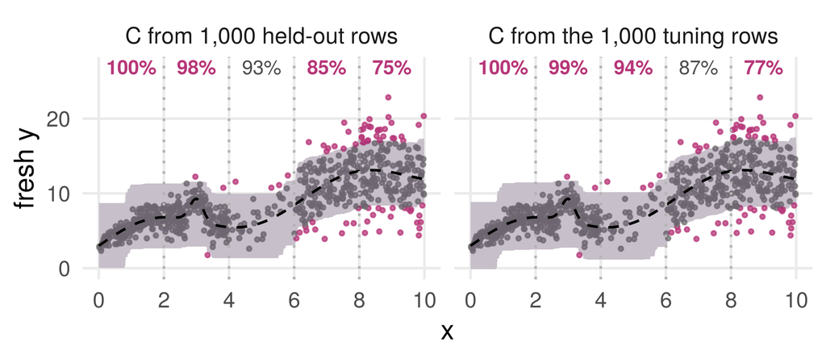

**Split conformal** (Lei et al. 2018): $C$ from 1,000 rows not used to fit, their 901st smallest absolute residual, $\lceil 0.9 \times 1001 \rceil$

Overall 90% and 91%, but not in every range

The tuning rows chose the node size, so residuals on them may be slightly optimistic

Optimism theorem: training error underestimates the risk

## Coverage on average, and at every $x$

**Conformal coverage theorem** (split conformal: Lei et al. 2018). If the rows are independent draws from one distribution, then for any model $P\big(Y \in \hat C(X)\big) \ge 0.9$, on average over $X$: **marginal coverage**

**Conditional coverage**: $P\big(Y \in \hat C(X) \mid X = x\big) \ge 0.9$ at every $x$, what the one person wanted

One $C$ for every $x$, and noise that grows with $x$: too wide where the noise is small, too narrow where it is large, whatever $n$

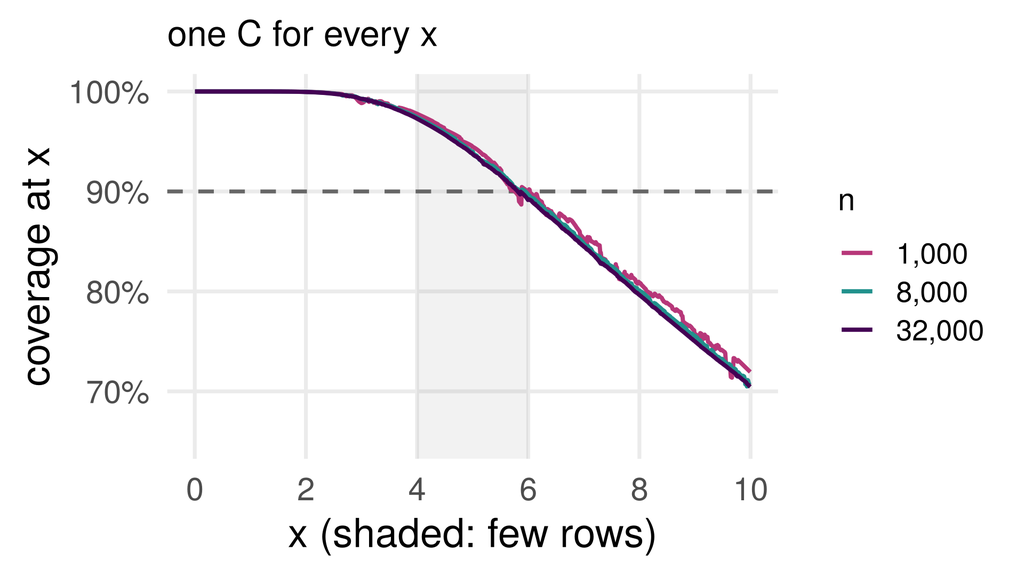

## Coverage at every $x$, as $n$ grows

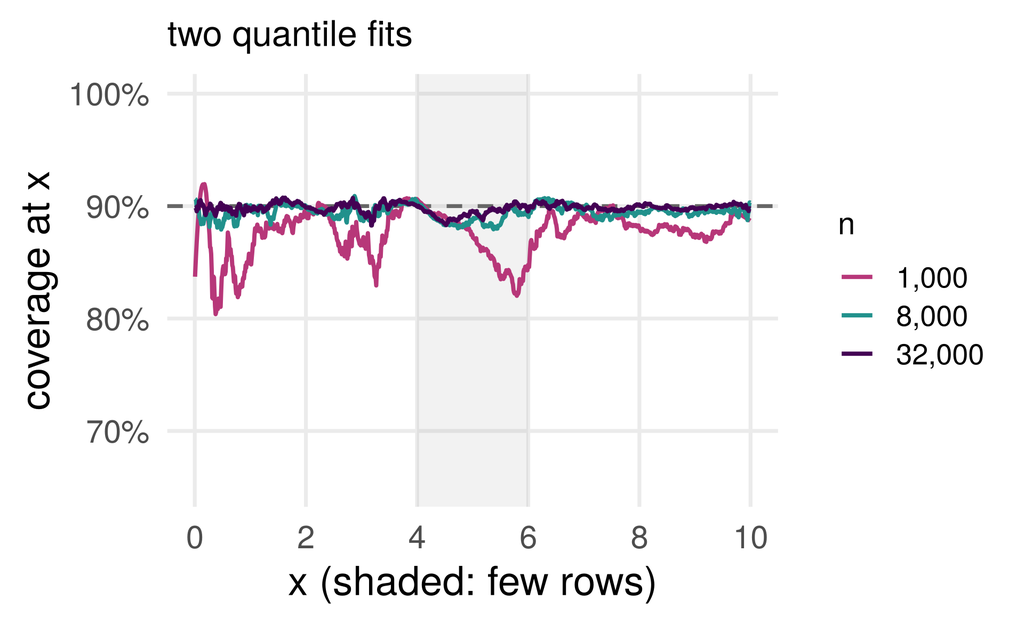

Edges fitted near each $x$: two quantile fits on $n$ rows. The noise is known, so coverage at each $x$ can be computed exactly; here averaged over 30 fits

- At $n$ = 1,000 it dips where the quantiles change fast relative to the noise (near 0, at the bump) and where the rows are few (4 to 6)
- The dips fill in as $n$ grows, **if** the fits approach the true quantiles (**consistency**)

## Coverage at every $x$ in many dimensions

An interval at $x$ is learned from the $n_x$ rows near $x$. Its coverage there misses 90% by

- **Variance**: about $\sqrt{0.9 \times 0.1 / n_x}$: 4 points with 50 rows, 1.3 with 500
- **Bias**: rows farther from $x$ have different quantiles. Edges off by half a noise standard deviation: 86%, not 90%

More inputs, fewer rows near $x$. 2,000 rows, 5 bins for each input:

| Inputs | 1 | 2 | 3 | 5 |
| --- | --- | --- | --- | --- |
| Rows per bin, $n_x$ | 400 | 80 | 16 | 0.6 |
| $\sqrt{0.9 \times 0.1 / n_x}$, points | 1.5 | 3.4 | 7.5 | – |

Curse of dimensionality: in ten dimensions, a cube holding 10% of the population spans 79% of each axis

## Conditional coverage without assumptions

Fits that approach the true quantiles, enough rows near $x$, quantiles that change slowly: each is an assumption about the distribution. With none:

**Impossibility of distribution-free conditional coverage.** If a procedure covers with probability at least $1 - \alpha$ given $X = x$, in finite samples, for every distribution and almost every $x$, then wherever the inputs are continuous its intervals have infinite expected length (Barber et al. 2021). Guarantees for groups (each range of $x$, say), and results under assumptions or as $n$ grows, remain possible

No free lunch theorem: no method does best on every distribution; a guarantee at every $x$ needs an assumption about the distribution

## Ways to make an interval

| Method | Assumes | Can claim |
| --- | --- | --- |
| Linear model, normal noise | linear mean, constant variance | 90% at every $x$, if right |
| Mean and variance models | both right, normal noise | about 90% at every $x$, if right |
| Quantile regression | the quantile model right | 90% at every $x$ as $n$ grows, if right |
| Split conformal (Lei et al. 2018) | exchangeable rows | at least 90% marginally; one width |
| CQR (Romano et al. 2019) | exchangeable rows | at least 90% marginally; widths from the fits; at every $x$ as $n$ grows, if the fits are consistent |

More in the note on the course page, “Prediction intervals and calibration”; CQR is also on the slide after the conclusion

### Part 2: classification uncertainty and calibration

## Data: NHANES

The US National Health and Nutrition Examination Survey, 2009 to 2012 (R package `NHANES`): interviews and physical examinations. We use 9,212 adults aged 20 and over

| Outcomes | **diabetes**, as told by a doctor (14% yes); later, **systolic blood pressure** (mm Hg) |
| --- | --- |
| Measurements | age, gender, weight, height, BMI, pulse, total and HDL cholesterol, family income relative to the poverty line, physically active or not |
| Groups | race and ethnicity, in the survey’s five groups |
| Split | at random: 4,000 training adults; 3,000 tuning adults; 2,212 test adults, used once |

- Not a sample of the US population: the survey samples some groups at higher rates, and we do not use its weights

## Calibration

A model gives $\hat p = 0.2$ to 500 adults: their probability of having diabetes. What should be true of them?

About 100 of them should have diabetes. A score $\hat p$ is **calibrated** if
$$P\big(Y = 1 \mid \hat p(X)\big) = \hat p(X)$$

The same idea as coverage: a stated probability should match a frequency. It conditions on the score, not on $x$

## Calibration and decisions

A probability is acted on: a risk told to a patient, a premium set from an expected cost, a threshold set from the costs of errors

- The optimal threshold theorem cuts the true $p(x)$ at $c^\star$; we have only $\hat p$. If $\hat p$ is calibrated, cutting it at $c^\star$ is optimal among rules based on that score
- If not, $c^\star$ can pick the wrong people. At $c^\star = 0.25$, adults given $\hat p = 0.2$, of whom 40% have diabetes, are not referred for a test, although referring them costs less on average
- Calibration is not accuracy. The base rate, $0.14$ for every adult, is calibrated and separates no one. An increasing transformation keeps a score’s ranking (and AUC), not its calibration

Optimal threshold theorem: with costs $c_{FP}$ and $c_{FN}$, the rule that minimizes expected cost at $x$ predicts $1$ exactly when $p(x) > c^\star = c_{FP}/(c_{FP} + c_{FN})$

## Reliability diagram

Adults in ten bins by score: each bin’s share with diabetes against its average score. Two scores from nine measurements, on the 4,000 **training** adults used to fit them

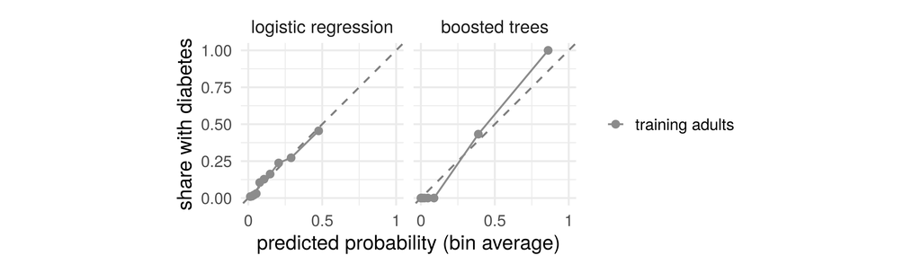

On the diagonal: calibrated. On their own adults, logistic regression is; the boosted trees look too cautious at the top

## Reliability on fresh adults

The same two scores on 3,000 **tuning** adults, who played no part in fitting them

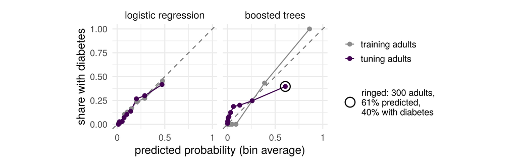

Logistic regression (10 coefficients) hardly moves. Boosted trees (100 trees): too confident at the top, the opposite of what their training adults said

## Recalibration

A map from the old score to a new one, learned on half the tuning adults, checked on the other half: a logistic regression of the label on $\mathrm{logit}\,\hat p$, giving $\mathrm{logit}\,\tilde p = a + b\,\mathrm{logit}\,\hat p$

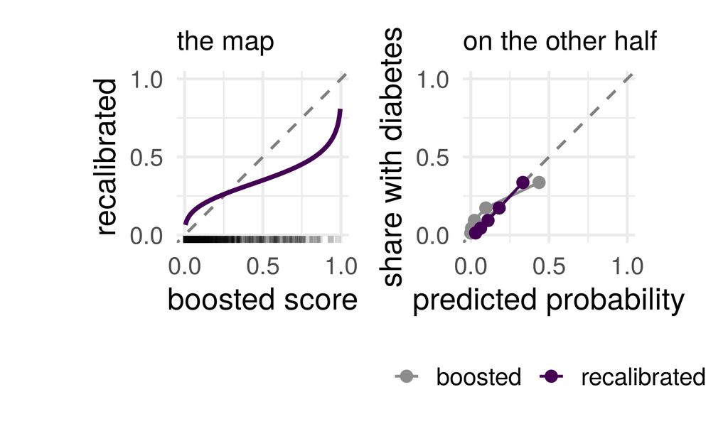

For $b > 0$ the map is increasing: the same ranking, new probabilities. $b = 0.39$: two adults whose boosted log-odds differ by 1 differ by 0.39 after. Log loss on the other half: 0.375 to 0.329

## Calibration within groups

One score for everyone: the logistic score, with race and ethnicity left out of its inputs. Is it calibrated within each group?

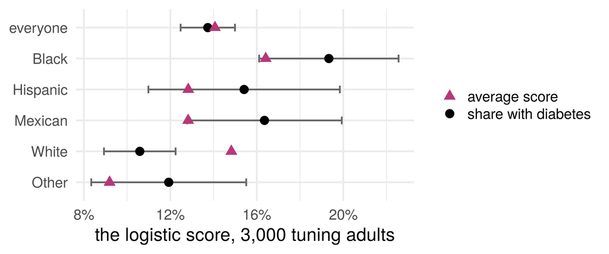

White adults: average score 14.8%, 10.6% with diabetes, a gap of 5.1 standard errors; the other gaps are about 2 standard errors or less

## Calibration and fairness

- A score that is too high for one group and too low for another, cut at one threshold, refers the first group for tests more often, and the second less often, than their risk warrants
- The score **discriminates**, even with race and ethnicity left out of its inputs
- Calibration within groups is one fairness criterion among several, and they conflict: with different base rates, no imperfect score is calibrated within groups and also averages the same in each group among adults with diabetes, and among those without (Kleinberg et al. 2017)

## Multicalibration

**Multicalibration** (Hébert-Johnson et al. 2018): calibrated in every group named in advance, at every range of scores. In each group and tenth of the scores, shift the scores by the gap; repeat

Learned on the tuning adults, checked on the test adults. Gap in standard errors:

- White (1,001 adults): 2.0 to 0.6
- Mexican American (317): 0.7 to 2.4

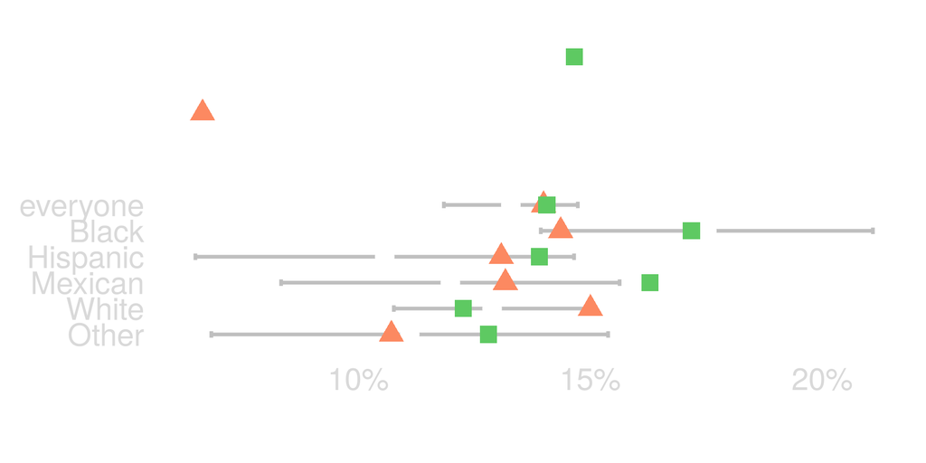

It fixes the gap the data can establish. A gap of 2 or 3 points in a group of a few hundred is within noise, and a shift fitted to it does not carry over

### Part 3: interpreting the model

## One predictor at a time

**How does the model use one specific predictor, $x_2$, say?** For linear regression this is simple: its coefficient. With flexible models the answer changes depending on where you look in the input space

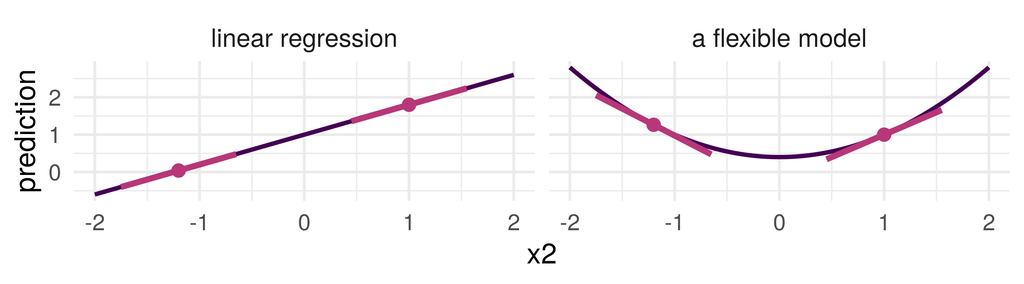

We can change $x_2$ to see how the predictions vary, but what do we do with the other predictors?

## Partial dependence for any model (not just GAM)

Options for the other inputs: hold them fixed (at medians, say: `plotmo`’s default); average over them (partial dependence, `pdp`); one curve for each unit (individual conditional expectation, ICE)

Unit $i$’s inputs with input $j$ set to a value $t$, the others left as they are:
$$\mathrm{ICE}_i(t) = \hat f(x_{i1}, \ldots, t, \ldots, x_{ip}), \qquad
\mathrm{PDP}_j(t) = \frac1n \sum_{i=1}^n \hat f(x_{i1}, \ldots, t, \ldots, x_{ip})$$

Compute on a grid of $t$ values and plot the curve(s)

ICE evaluates $\hat f$ at a modified input, which may correspond to no plausible unit

## Does this forest use $x_1$?

```r
fit_rf <- randomForest(y ~ x1 + x2, data = df_int, ntree = 300, mtry = 2, nodesize = 50)
ice_x1 <- partial(fit_rf, pred.var = "x1", ice = TRUE, train = df_sub)
```

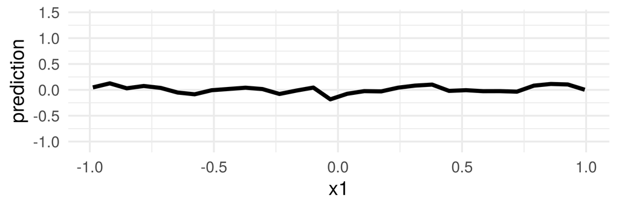

The PDP: $x_1$ set, $x_2$ at each unit’s value, predictions averaged over 100 units

## The forest’s ICE curves

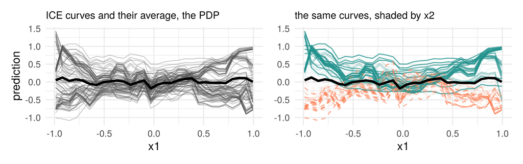

Thin: one curve per unit (ICE). Right: solid where $\cos(\pi x_2/2) > 0$, dashed where it is negative, more opaque the larger $|\cos(\pi x_2/2)|$. The forest fitted the interaction, PDP hides it, and ICE might show it

## Every predictor at once

What if we don’t have one specific predictor of interest, but want to know how the model uses all the predictors?

- For one prediction: split it among the inputs (**Shapley values**)
- For the whole model: one number for each input (**importance**)

## Shapley values

Split a prediction among the inputs, $\hat f(\mathbf x_i) - v_i(\varnothing) = \phi_{i1} + \dots + \phi_{ip}$; $v_i(S)$ predicts from the inputs in $S$ only (usually: the others averaged over the data, as in partial dependence). For two inputs, adding $x_1$ in either order (for $p$, all $p!$ orders):
$$\phi_{i1} = \tfrac12\Big[\big(v_i(\{1\}) - v_i(\varnothing)\big) + \big(v_i(\{1, 2\}) - v_i(\{2\})\big)\Big]$$

The forest, one unit with $x_1 = 1.00$ and $x_2 = 0.06$:

| $v_i(\varnothing)$ | $v_i(\{1\})$ | $v_i(\{2\})$ | $v_i(\{1, 2\}) = \hat f(\mathbf x_i)$ |
| --- | --- | --- | --- |
| -0.00 | -0.08 | 0.19 | 0.92 |

$\phi_{i1} = \frac12\big[(-0.08 - -0.00) + (0.92 - 0.19)\big] = 0.325$

$\phi_{i2} = \frac12\big[(0.19 - -0.00) + (0.92 - (-0.08))\big] = 0.595$; together 0.92 $= 0.92 - -0.00 = \hat f(\mathbf x_i) - v_i(\varnothing)$

## Shapley values for one adult

We now use the same NHANES adults to predict **systolic blood pressure** (mm Hg): a forest on nine inputs, fitted on the 4,000 training adults

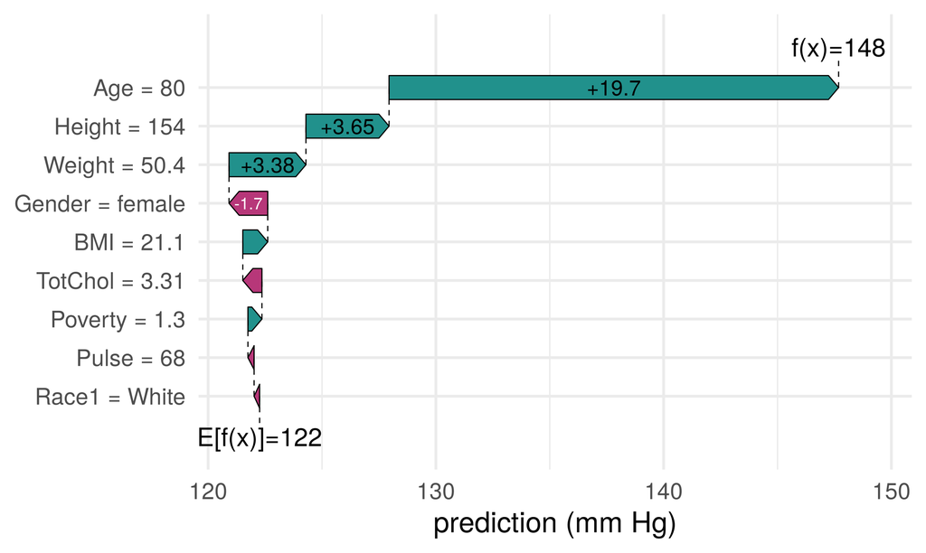

A **waterfall plot** (SHAP: Lundberg and Lee 2017). It starts at the average prediction over the background adults, $v_i(\varnothing)$, adds each input’s $\phi_{ij}$, largest first, and ends at this adult’s prediction $\hat f(\mathbf x_i)$

The adult with the highest prediction of 200 tuning adults

## Feature/variable “importance”

- Which predictors are *used most* by the model? The forest for systolic blood pressure

#### Tree-specific importance ■

Sum the RSS decrease of every split on $x_j$ within a tree, then average over trees

#### Permutation importance ▲

Permute values of predictor $x_j$. How much does the accuracy of the model decrease?
$$\mathrm{PI}_j = \widehat{\mathrm{Err}}(\hat f, x_j \text{ permuted}) - \widehat{\mathrm{Err}}(\hat f)$$

#### Leave one covariate out ◆

Refit without input $j$, with the same settings; score on the same held-out adults (Lei et al. 2018):
$$\mathrm{LOCO}_j = \widehat{\mathrm{Err}}\big(\hat f^{(-j)}\big) - \widehat{\mathrm{Err}}(\hat f)$$

No extrapolation from permuting; any method, at the cost of $p$ refits

## Importance on the forest

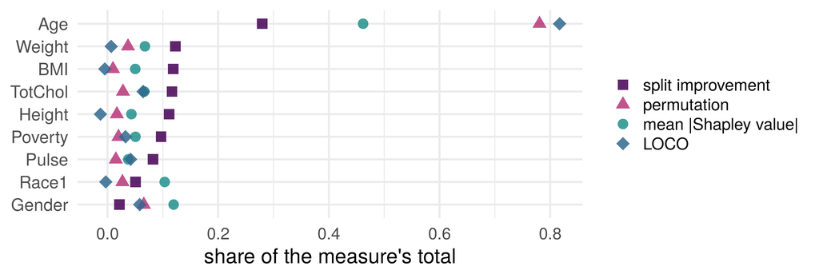

- Does not necessarily tell us about **causation** (none of these methods do)
- Each has pros/cons, no satisfactory answer for dependence

## Permutation with correlated inputs

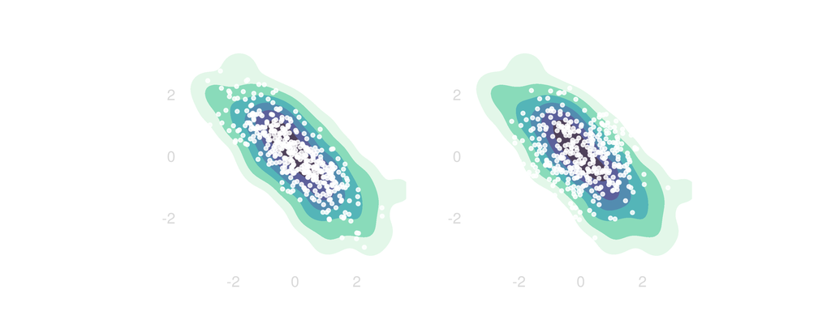

Where the data’s density is below 0.01: 21% of the permuted points, 2% of the data

## Permutation and extrapolation

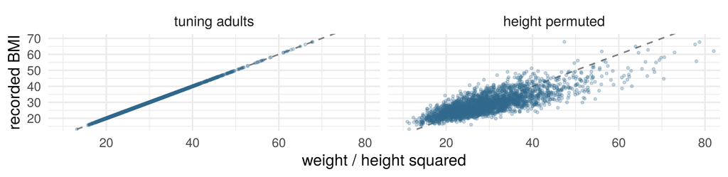

Shuffling height keeps each adult’s weight and BMI: BMI no longer matches weight and height for 69% of them (0% before); 38 are under 155 cm and over 110 kg (4 before)

The forest’s predictions there rest on almost no data, and permutation importance averages over them (Hooker, Mentch and Zhou 2021)

### Part 4: the model and the world

Background: after Loftus, Bynum and Hansen (2024), Figure 5

## Predictions and outcomes

A partial dependence plot for $x_1$ leaves $x_2$ and $x_3$ at each unit’s value. In the world, they respond to $x_1$. To let them respond, what do we need besides the fitted model?

A causal model for the inputs. An **explanatory causal model** (ECM; Loftus, Bynum and Hansen 2024) adds the prediction $\hat Y = \hat f(X)$, with dashed arrows from the model’s inputs. Here $x_3$ depends on $y$, so $y$ is in it too:

$x_2 = x_1 + \varepsilon_2$, $\ y = \tfrac12 x_1 + \tfrac32 \sin x_2 + \varepsilon$, $\ x_3 = y + x_1 + \varepsilon_3$; $\hat f$, a forest on $x_1, x_2, x_3$

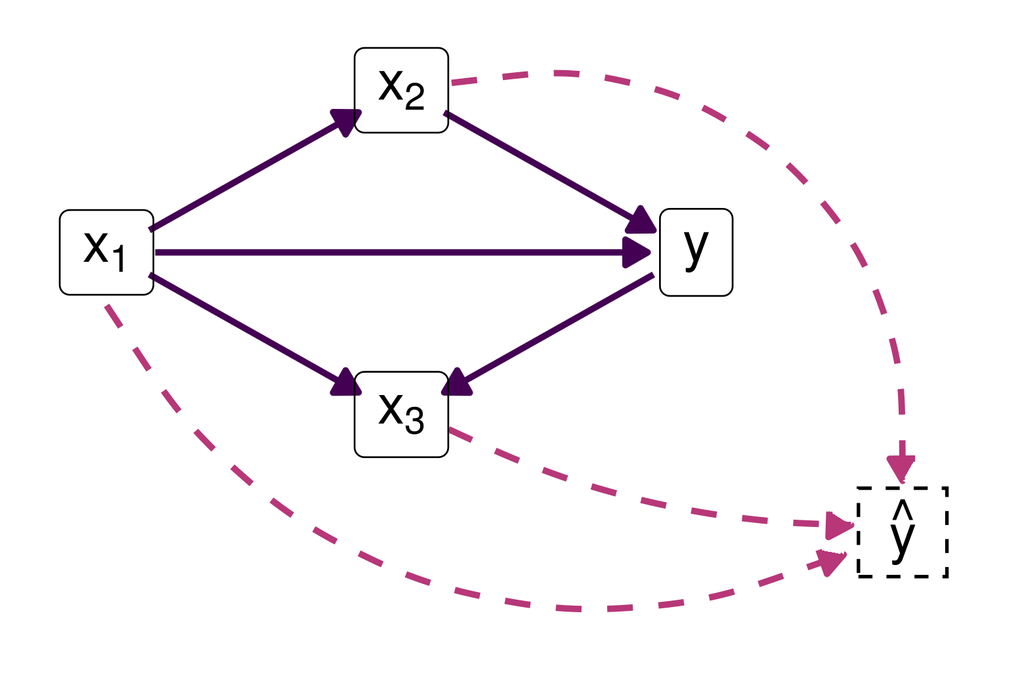

## Natural direct and total dependence

In the ECM, set $x_1 = t$ for every unit, predict, average, with $x_2$ and $x_3$

- left at each unit’s value: the **natural direct dependence plot** (NDDP), which is the PDP
- recomputed from their equations: the **total dependence plot** (TDP), $\mathbb E[\hat f(X) \mid do(x_1 = t)]$

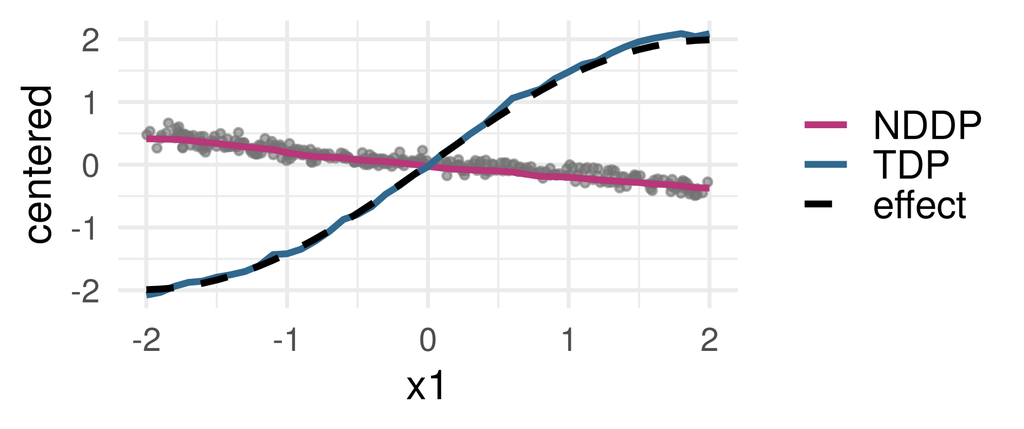

NDDP falls: with $x_3$ held fixed, a larger $x_1$ means a smaller $y$. TDP follows the effect of setting $x_1$ (dashed). Grey: Shapley values for $x_1$

**Causal Shapley values** (Heskes et al. 2020) put $do(\cdot)$ in place of conditioning

## Partial dependence and causal effects

- If the **adjustment theorem’s assumptions hold**, with the plotted input as $T$ and the model’s other inputs as $Z$, and the **model fits the true regression function well**, then the PDP can show the causal effect of $T$ on the outcome (Zhao and Hastie 2021)
- Whatever the causal structure, the PDP shows the natural direct effect of the plotted input **on the predicted outcome** $\hat Y$ (Loftus, Bynum and Hansen 2024)

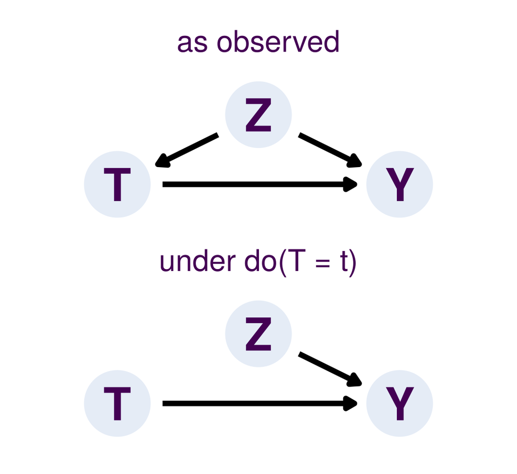

Adjustment theorem: $Z$ holds every common cause of $T$ and $Y$, and no consequence of $T$

## Conclusion

#### Uncertainty

The loss decides which number is the best prediction; the pinball loss gives a quantile. Residuals from held-out rows give an interval that covers 90% on average, for any model. Coverage at every $x$ needs edges fitted near $x$, enough rows there, and assumptions: no method guarantees it in finite samples without them. Check coverage and calibration on data not used to fit or tune, across the range of the inputs and within groups

#### Interpretation

Partial dependence, ICE, Shapley values and importance describe $\hat f$. If the adjustment theorem’s assumptions hold and the model fits well, the PDP can show a causal effect; with a causal model for the inputs, the total dependence plot answers a different question

## Conformalized quantile regression

1. Fit $\hat q_{0.05}$, $\hat q_{0.95}$ on some training rows; keep $m$ others, the **calibration set**
2. Score how far each $y_i$ is outside (negative inside): $E_i = \max\{\hat q_{0.05}(x_i) - y_i,\ y_i - \hat q_{0.95}(x_i)\}$
3. $Q$: the $\lceil 0.9\,(m + 1) \rceil$-th smallest score
4. $\hat C(x) = \big[\hat q_{0.05}(x) - Q,\ \hat q_{0.95}(x) + Q\big]$

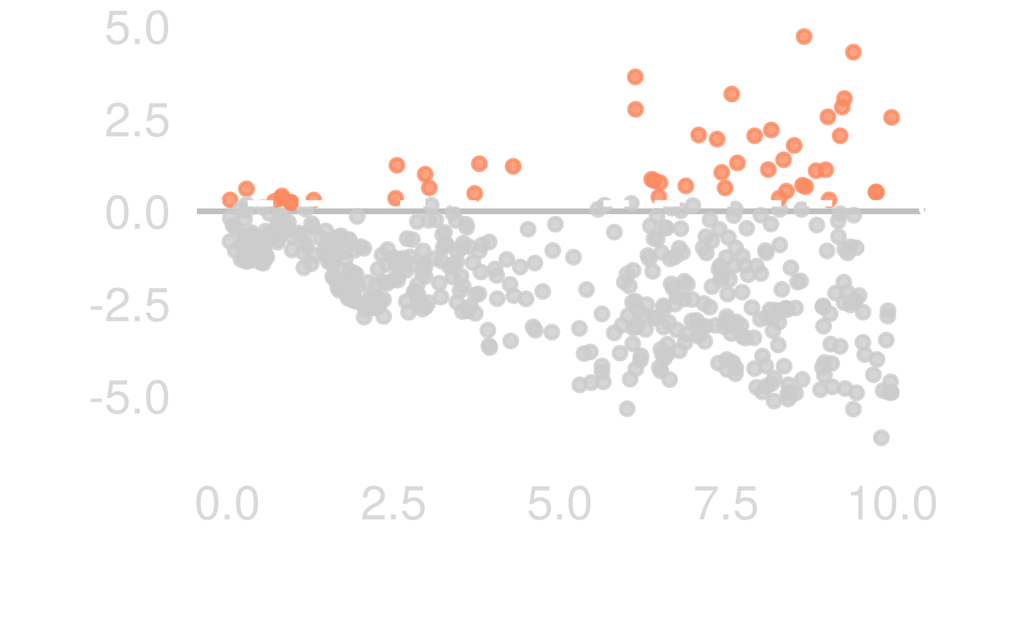

$m = 500$, $Q = 0.21$: 87% to 89%; for $x$ in 4–6, 92% to 93%

**The conformal coverage theorem holds for any quantile fits** (Romano et al. 2019): $P(Y \in \hat C(X)) \ge 0.9$, and $\le 0.9 + 1/(m + 1)$ for continuous scores. If the fits are consistent, $Q \to 0$ and coverage at every $x$ approaches 90% (Sesia and Candès 2020)

## Exchangeable rows and atoms

These slides state two conditions more simply than the sources do:

- **Exchangeable rows.** The conformal coverage theorem (Lei et al. 2018; Romano et al. 2019, Theorem 1) needs only rows $(X_1, Y_1), \dots, (X_{m+1}, Y_{m+1})$ whose joint distribution is unchanged when they are reordered: **exchangeable** rows. Independent draws from one distribution are exchangeable; draws without replacement from a finite population are exchangeable but not independent.
- **Atoms.** The impossibility theorem (Barber et al. 2021, Proposition 2.2) is about each $x$ that is not an **atom**, a value with positive probability; continuous inputs have no atoms. The upper bound $1 - \alpha + 1/(m + 1)$ needs only scores that are distinct with probability one
- Sesia and Candès (2020) do assume independent rows from one distribution

## References (1 of 3)

- Barber, R. F., Candès, E. J., Ramdas, A. and Tibshirani, R. J. (2021). The limits of distribution-free conditional predictive inference. *Information and Inference: A Journal of the IMA* 10(2), 455–482. [doi:10.1093/imaiai/iaaa017](https://doi.org/10.1093/imaiai/iaaa017). The result stated is Proposition 2.2, p. 459.
- Chen, H., Janizek, J. D., Lundberg, S. and Lee, S.-I. (2020). True to the model or true to the data? arXiv:2006.16234. arxiv.org/abs/2006.16234
- Chouldechova, A. (2017). Fair prediction with disparate impact: a study of bias in recidivism prediction instruments. *Big Data* 5(2), 153–163. [doi:10.1089/big.2016.0047](https://doi.org/10.1089/big.2016.0047)
- Hébert-Johnson, Ú., Kim, M. P., Reingold, O. and Rothblum, G. N. (2018). Multicalibration: calibration for the (computationally-identifiable) masses. *Proceedings of the 35th International Conference on Machine Learning*, PMLR 80, 1939–1948. proceedings.mlr.press/v80/hebert-johnson18a.html. Definition 2.6 and section 3.2 as numbered in the arXiv version, 1711.08513

## References (2 of 3)

- Heskes, T., Sijben, E., Bucur, I. G. and Claassen, T. (2020). Causal Shapley values: exploiting causal knowledge to explain individual predictions of complex models. *Advances in Neural Information Processing Systems* 33. [NeurIPS proceedings](https://papers.nips.cc/paper/2020/hash/32e54441e6382a7fbacbbbaf3c450059-Abstract.html)
- Hooker, G., Mentch, L. and Zhou, S. (2021). Unrestricted permutation forces extrapolation: variable importance requires at least one more model, or there is no free variable importance. *Statistics and Computing* 31(6), article 82. [doi:10.1007/s11222-021-10057-z](https://doi.org/10.1007/s11222-021-10057-z)
- Kleinberg, J., Mullainathan, S. and Raghavan, M. (2017). Inherent trade-offs in the fair determination of risk scores. *8th Innovations in Theoretical Computer Science Conference (ITCS 2017)*, LIPIcs 67, 43:1–43:23. [doi:10.4230/LIPIcs.ITCS.2017.43](https://doi.org/10.4230/LIPIcs.ITCS.2017.43)
- Lei, J., G’Sell, M., Rinaldo, A., Tibshirani, R. J. and Wasserman, L. (2018). Distribution-free predictive inference for regression. *Journal of the American Statistical Association* 113(523), 1094–1111. Section 2.2 (split conformal) and section 6 (LOCO). [doi:10.1080/01621459.2017.1307116](https://doi.org/10.1080/01621459.2017.1307116)
- Loftus, J. R., Bynum, L. E. J. and Hansen, S. (2024). Causal dependence plots. *Advances in Neural Information Processing Systems* 37. Definitions 2.5, 2.7 and 2.9, Theorem 2.10, Figure 5. [doi:10.52202/079017-3579](https://doi.org/10.52202/079017-3579)

## References (3 of 3)

- Lundberg, S. M. and Lee, S.-I. (2017). A unified approach to interpreting model predictions. *Advances in Neural Information Processing Systems* 30, 4765–4774. [NeurIPS proceedings](https://papers.nips.cc/paper/7062-a)
- Romano, Y., Patterson, E. and Candès, E. J. (2019). Conformalized quantile regression. *Advances in Neural Information Processing Systems* 32, 3543–3553. [NeurIPS proceedings](https://proceedings.neurips.cc/paper_files/paper/2019/hash/5103c3584b063c431bd1268e9b5e76fb-Abstract.html). Section 4, equations 6 to 8 and Theorem 1
- Sachs, K., Perez, O., Pe’er, D., Lauffenburger, D. A. and Nolan, G. P. (2005). Causal protein-signaling networks derived from multiparameter single-cell data. *Science* 308(5721), 523–529. [doi:10.1126/science.1105809](https://doi.org/10.1126/science.1105809)
- Sesia, M. and Candès, E. J. (2020). A comparison of some conformal quantile regression methods. *Stat* 9(1), e261. [doi:10.1002/sta4.261](https://doi.org/10.1002/sta4.261). Theorem 1 and its corollary, as numbered in arXiv:1909.05433
- Zhao, Q. and Hastie, T. (2021). Causal interpretations of black-box models. *Journal of Business and Economic Statistics* 39(1), 272–281. [doi:10.1080/07350015.2019.1624293](https://doi.org/10.1080/07350015.2019.1624293)